# Percentage of nuage-forming cells in 3∆ background Ede1 truncation mutants

Last compiled on March 21, 2022

## Experiment

### Rationale

I want to quantify the nuage-forming tendencies of each Ede1 truncation construct, in two yeast cell backgrounds (wild-type and *apl3∆ yap1801∆ yap1802∆*) Absent a more finely tuned method, I have counted the percentage of condensate-containing cells (by subjective but blinded assessment).

### Method

I acquired all data on the Olympus IX81 equipped with a 100x/1.49 objective, using the X-Cite 120PC lamp at 50% intensity and 400 ms exposure for illumination. Light was filtered through a U-MGFPHQ filter cube. I acquired stacks of 26 planes with a step size of 0.2 microns.

Individual cells were cropped out of fields of view based only on the bright field channel. I used the ImageJ macro `blindAnalysis` to sequentially display all images at random, blinding me to the strain of origin, and recording a binary decision about condensate formation for each image.

### Strain list

| strain | bg | Ede1 |
| --- | --- | --- |
| MKY0172 | wt | FL |
| MKY3546 | wt | 1-900 |
| MKY4083 | wt | 1-590 |
| MKY3548 | wt | 366-1381 |
| MKY3550 | wt | 591-1381 |
| MKY3552 | wt | 366-900 |
| MKY3554 | wt | 591-900 |
| MKY0532 | 3×ΔEA | FL |
| MKY3519 | 3×ΔEA | 1-590 |
| MKY3547 | 3×ΔEA | 1-900 |
| MKY3549 | 3×ΔEA | 366-1381 |
| MKY3551 | 3×ΔEA | 591-1381 |
| MKY3553 | 3×ΔEA | 366-900 |
| MKY3555 | 3×ΔEA | 591-900 |

## Data summary

### Individual datasets

Percentage of cells with condensates for each Ede1 construct in each background, by dataset.

x: number of cells with condensates, n: total number of analyzed condensates, p: x / n, p_min and p_max: estimates of binomial confidence interval based on sample size, by Wilson’s method.

| bg | Ede1 | dataset | x | n | p | p_min | p_max |
| --- | --- | --- | --- | --- | --- | --- | --- |
| wt | FL | 1 | 0 | 37 | 0.0000000 | 0.0000000 | 0.0940578 |
| wt | FL | 2 | 2 | 55 | 0.0363636 | 0.0100295 | 0.1232346 |
| wt | FL | 3 | 1 | 52 | 0.0192308 | 0.0009864 | 0.1012051 |
| wt | 1-900 | 1 | 0 | 68 | 0.0000000 | 0.0000000 | 0.0534713 |
| wt | 1-900 | 2 | 0 | 63 | 0.0000000 | 0.0000000 | 0.0574712 |
| wt | 1-900 | 3 | 5 | 65 | 0.0769231 | 0.0333035 | 0.1677593 |
| wt | 1-590 | 1 | 0 | 65 | 0.0000000 | 0.0000000 | 0.0558015 |
| wt | 1-590 | 2 | 0 | 53 | 0.0000000 | 0.0000000 | 0.0675820 |
| wt | 1-590 | 3 | 0 | 66 | 0.0000000 | 0.0000000 | 0.0550026 |
| wt | 366-1381 | 1 | 16 | 60 | 0.2666667 | 0.1713264 | 0.3900871 |
| wt | 366-1381 | 2 | 10 | 50 | 0.2000000 | 0.1124375 | 0.3303711 |
| wt | 366-1381 | 3 | 9 | 55 | 0.1636364 | 0.0885542 | 0.2826375 |
| wt | 591-1381 | 1 | 0 | 59 | 0.0000000 | 0.0000000 | 0.0611294 |
| wt | 591-1381 | 2 | 0 | 52 | 0.0000000 | 0.0000000 | 0.0687922 |
| wt | 591-1381 | 3 | 0 | 57 | 0.0000000 | 0.0000000 | 0.0631388 |
| wt | 366-900 | 1 | 35 | 78 | 0.4487179 | 0.3433437 | 0.5589063 |
| wt | 366-900 | 2 | 15 | 64 | 0.2343750 | 0.1474990 | 0.3513326 |
| wt | 366-900 | 3 | 28 | 53 | 0.5283019 | 0.3966008 | 0.6561776 |
| wt | 591-900 | 1 | 0 | 62 | 0.0000000 | 0.0000000 | 0.0583441 |
| wt | 591-900 | 2 | 0 | 53 | 0.0000000 | 0.0000000 | 0.0675820 |
| wt | 591-900 | 3 | 0 | 54 | 0.0000000 | 0.0000000 | 0.0664136 |
| 3×ΔEA | FL | 1 | 42 | 42 | 1.0000000 | 0.9162012 | 1.0000000 |
| 3×ΔEA | FL | 2 | 33 | 38 | 0.8684211 | 0.7267314 | 0.9424613 |
| 3×ΔEA | FL | 3 | 46 | 49 | 0.9387755 | 0.8347951 | 0.9789599 |
| 3×ΔEA | 1-900 | 1 | 35 | 71 | 0.4929577 | 0.3800515 | 0.6065869 |
| 3×ΔEA | 1-900 | 2 | 33 | 51 | 0.6470588 | 0.5098606 | 0.7636551 |
| 3×ΔEA | 1-900 | 3 | 35 | 51 | 0.6862745 | 0.5497300 | 0.7967232 |
| 3×ΔEA | 1-590 | 1 | 0 | 65 | 0.0000000 | 0.0000000 | 0.0558015 |
| 3×ΔEA | 1-590 | 2 | 1 | 50 | 0.0200000 | 0.0010259 | 0.1049544 |
| 3×ΔEA | 1-590 | 3 | 0 | 50 | 0.0000000 | 0.0000000 | 0.0713476 |
| 3×ΔEA | 366-1381 | 1 | 42 | 61 | 0.6885246 | 0.5640857 | 0.7906257 |
| 3×ΔEA | 366-1381 | 2 | 33 | 55 | 0.6000000 | 0.4681280 | 0.7188150 |
| 3×ΔEA | 366-1381 | 3 | 29 | 52 | 0.5576923 | 0.4233976 | 0.6840494 |
| 3×ΔEA | 591-1381 | 1 | 1 | 62 | 0.0161290 | 0.0008273 | 0.0858672 |
| 3×ΔEA | 591-1381 | 2 | 0 | 43 | 0.0000000 | 0.0000000 | 0.0820098 |
| 3×ΔEA | 591-1381 | 3 | 0 | 47 | 0.0000000 | 0.0000000 | 0.0755576 |
| 3×ΔEA | 366-900 | 1 | 45 | 50 | 0.9000000 | 0.7863977 | 0.9565242 |
| 3×ΔEA | 366-900 | 2 | 35 | 42 | 0.8333333 | 0.6939600 | 0.9168408 |
| 3×ΔEA | 366-900 | 3 | 35 | 46 | 0.7608696 | 0.6206486 | 0.8608782 |
| 3×ΔEA | 591-900 | 1 | 1 | 57 | 0.0175439 | 0.0008999 | 0.0929075 |
| 3×ΔEA | 591-900 | 2 | 0 | 40 | 0.0000000 | 0.0000000 | 0.0876216 |
| 3×ΔEA | 591-900 | 3 | 0 | 42 | 0.0000000 | 0.0000000 | 0.0837988 |

### Averaged datasets

| bg | Ede1 | mean | sd | n |
| --- | --- | --- | --- | --- |
| wt | FL | 0.0185315 | 0.0181919 | 3 |
| wt | 1-900 | 0.0256410 | 0.0444116 | 3 |
| wt | 1-590 | 0.0000000 | 0.0000000 | 3 |
| wt | 366-1381 | 0.2101010 | 0.0522526 | 3 |
| wt | 591-1381 | 0.0000000 | 0.0000000 | 3 |
| wt | 366-900 | 0.4037983 | 0.1520250 | 3 |
| wt | 591-900 | 0.0000000 | 0.0000000 | 3 |
| 3×ΔEA | FL | 0.9357322 | 0.0658422 | 3 |
| 3×ΔEA | 1-900 | 0.6087637 | 0.1021897 | 3 |
| 3×ΔEA | 1-590 | 0.0066667 | 0.0115470 | 3 |
| 3×ΔEA | 366-1381 | 0.6154056 | 0.0667628 | 3 |
| 3×ΔEA | 591-1381 | 0.0053763 | 0.0093121 | 3 |
| 3×ΔEA | 366-900 | 0.8314010 | 0.0695853 | 3 |
| 3×ΔEA | 591-900 | 0.0058480 | 0.0101290 | 3 |

## Plots

### Lineplot

This is a difficult plot because of the number of variables involved: Ede1 truncation, strain background & dataset. First all on one plot, and means as thick lines.

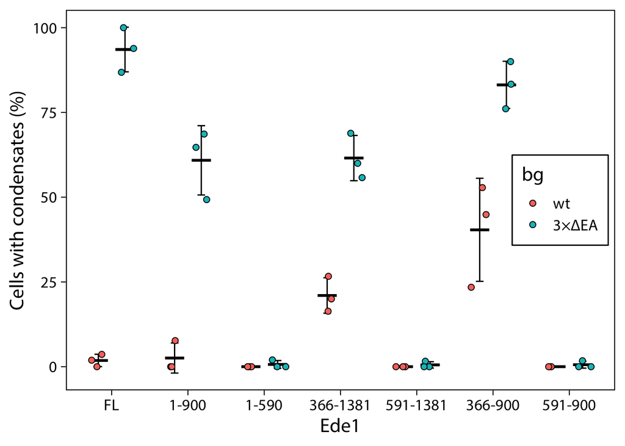

### Bar graph

The lines here do not provide enough visual cues as to which mean and point belongs to which combination of groups. As disliked as bar graphs are, I think in this case they would be much better suited to guide the reader.

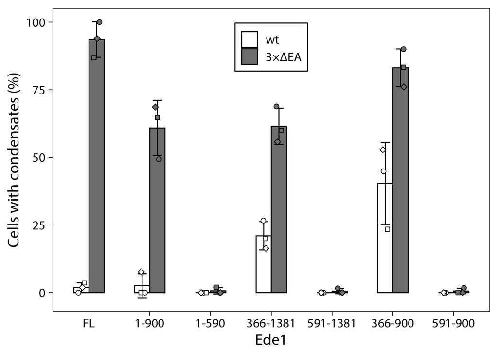

### Faceted line plot

Finally, for the easily confused (by multiple groupings) and the easily offended (by bar graphs), go back to lines but facet the two backgrounds.

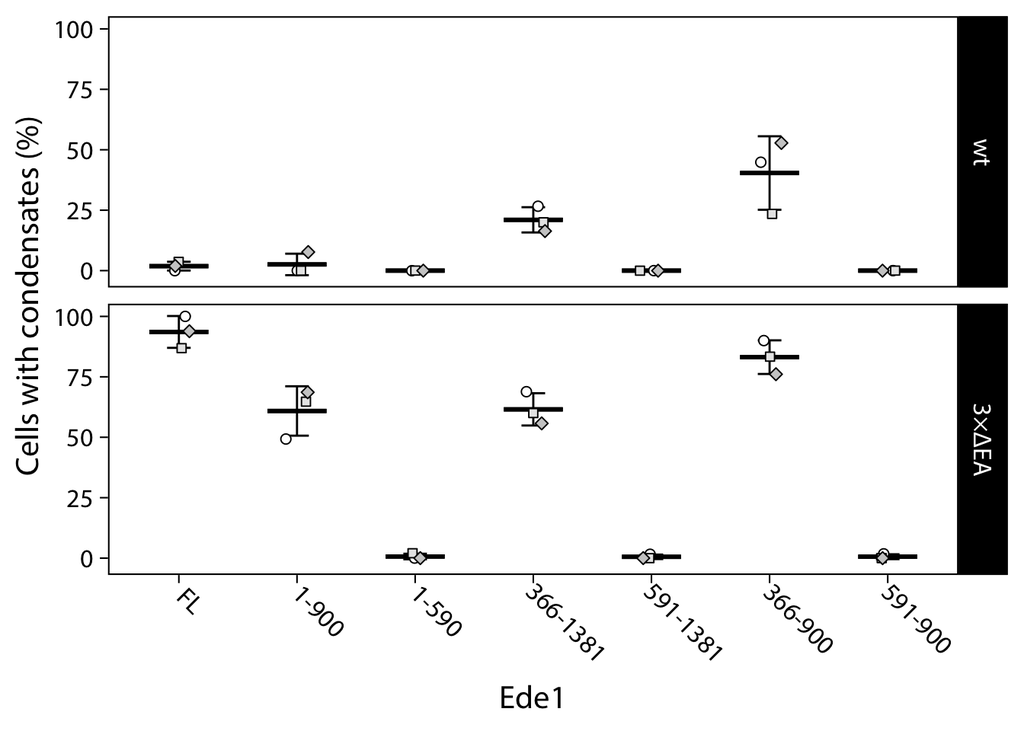

## Source data

### .csv

Download truncation_data.csv

### .RData

Download truncation_data.RData